# Dumbbell workout efficiency analysis

Bertrand Dolimier

12/14/2016

Using devices such as Jawbone Up, Nike FuelBand, and Fitbit it is now possible to collect a large amount of data about personal activity relatively inexpensively. These type of devices are part of the quantified self movement – a group of enthusiasts who take measurements about themselves regularly to improve their health, to find patterns in their behavior, or because they are tech geeks.

One thing that people regularly do is quantify how much of a particular activity they do, but they rarely quantify how well they do it. In this project, your goal will be to use data from accelerometers on the belt, forearm, arm, and dumbell of 6 participants. They were asked to perform barbell lifts correctly and incorrectly in 5 different ways.

Approach: We will split the training dataset into a “real” training and validation datasets. Will explore liner regression as a method to resolve the testing dataset (even if all indicators lead us to believe this is a classification problem). If LR is not conclusive we will still use result to select the fields correlated with the “classe” field to apply to the subsequent methods. We will then try Tree, Random Forest, Bagging and Boosting, we will keep the method with best accuracy results on the validation dataset and apply that method on the testing dataset for final prediction.

# Libraries / Loading raw data / Inititiatization

We will split the training dataset into a training of 10% and validation 90%

```
## for a complete list of changes.
```

# Linear Regression exploration

# Select training numeric fields not null and with minimum correlation with the classe column

# Display plot to confirm fields selected are correlated

We will first remove all fields with no significant values in the test dataset, then explore the correlation betwen the remaining fields and the classe field and keep on a selected fields. Listed in this code chunk.

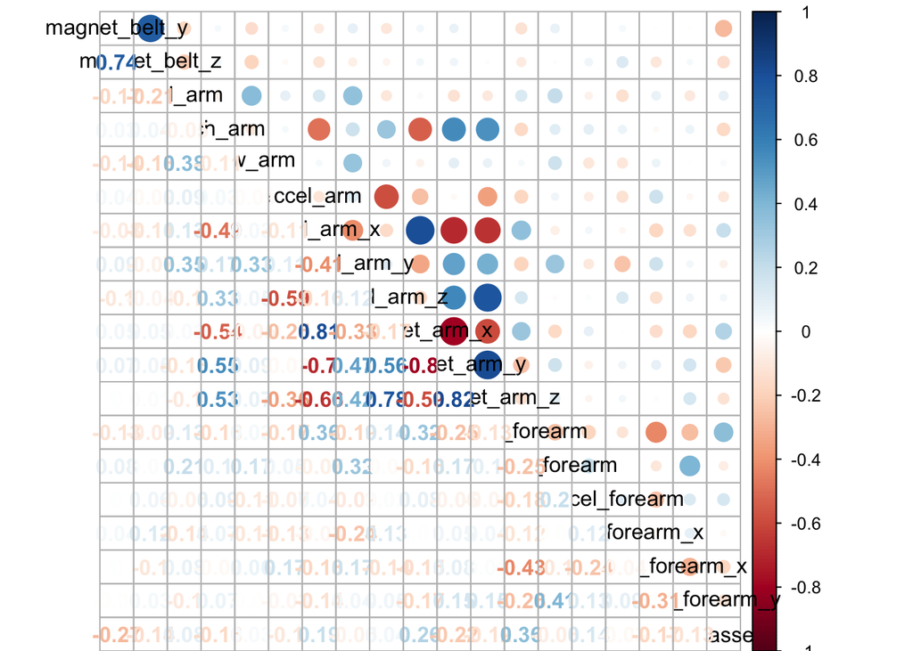

# Linear Regression plot

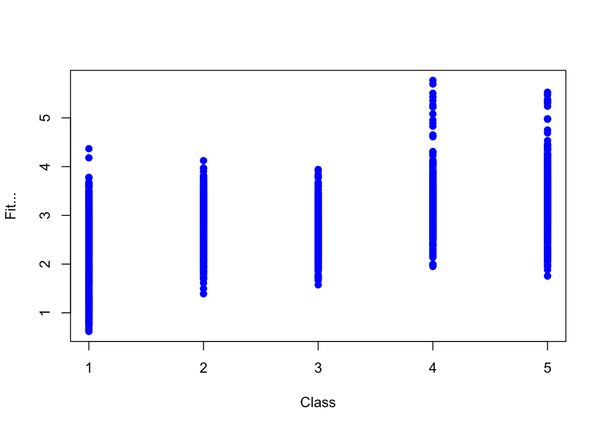

We selected 15 fields from the training dataset base on their correlation showed on the plot above. That subset will be used as predictors for the methods below.

# Tree

First method explore, the “tree” method aka “rpart” in the caret package. We find the accuracy between on the validation dataset to be 40% which clearly not satisfactory.

```
## CART
##
## 1964 samples
##   15 predictor
##    5 classes: 'A', 'B', 'C', 'D', 'E'
##
## No pre-processing
## Resampling: Bootstrapped (25 reps)
## Summary of sample sizes: 1964, 1964, 1964, 1964, 1964, 1964, ...
## Resampling results across tuning parameters:
##
##   cp          Accuracy   Kappa
##   0.01635846  0.4659202  0.3244490
##   0.02204836  0.4446375  0.2966058
##   0.04054054  0.3762682  0.1814430
##
## Accuracy was used to select the optimal model using  the largest value.
## The final value used for the model was cp = 0.01635846.
```

```
##
##            A    B    C    D    E
##   FALSE 1988 3417  991 1386 2152
##   TRUE  3034    0 2088 1508 1094
```

```
##
## pred    A    B    C    D    E
##    A 3034  885  588  474  464
##    B    0    0    0    0    0
##    C 1426 1868 2088  673 1073
##    D  558  647  395 1508  615
##    E    4   17    8  239 1094
```

```
## n= 1964
##
## node), split, n, loss, yval, (yprob)
##       * denotes terminal node
##
##  1) root 1964 1406 A (0.28 0.19 0.17 0.16 0.18)
##    2) pitch_forearm< -27.3 165    6 A (0.96 0.036 0 0 0) *
##    3) pitch_forearm>=-27.3 1799 1400 A (0.22 0.21 0.19 0.18 0.2)
##      6) magnet_belt_y>=557.5 1655 1256 A (0.24 0.23 0.21 0.18 0.15)
##       12) pitch_forearm< 24.65 1102  790 A (0.28 0.25 0.23 0.091 0.15)
##         24) accel_arm_y< -39.5 418  232 A (0.44 0.19 0.13 0.13 0.11) *
##         25) accel_arm_y>=-39.5 684  484 C (0.18 0.29 0.29 0.067 0.17) *
##       13) pitch_forearm>=24.65 553  360 D (0.16 0.18 0.16 0.35 0.16)
##         26) magnet_arm_y>=316 124   82 C (0.23 0.27 0.34 0.089 0.065) *
##         27) magnet_arm_y< 316 429  247 D (0.14 0.15 0.11 0.42 0.18) *
##      7) magnet_belt_y< 557.5 144   30 E (0 0.0069 0 0.2 0.79) *
```